# Lab5

Max Wang  
PHYS 434  
Lab 5  
Partner: Alexander Hyde

```python
%matplotlib inline
import numpy as np
import math
import matplotlib
import matplotlib.pyplot as plt
import scipy
from scipy import stats
import pickle
plt.rcParams['figure.figsize'] = (20,10)

infile = open ("C:/Users/wangj/EECS/higgs_100000_pt_250_500.pkl",'rb')
higgs = pickle.load(infile)

infile = open ("C:/Users/wangj/EECS/qcd_100000_pt_250_500.pkl",'rb')
qcd = pickle.load(infile)
```

## Features

`pt` is the transverse momentum of scattered particles from the collision. It is derived from the x and y components of the momentum $p_t$$\equiv$$(p_x, p_y)$, as the beam trajectary typically lies in the z-axis.

`eta` is the pesudorapidity of scattered particles from the beam. The exact equation is $\eta\equiv{ln[ cot(\frac{\theta}2)}]$, which is a function of polar angle θ where θ ranges from 0 to $\pi$. The equation also indicates logrithmic nature to its values.

`phi` is the azimutal angle $\phi$ perpendicular around the beam. Again, as the beam trajectory typically lies in the z-axis, $\phi$ is the angle of $p_t$ in the xy-plane, or the "Transverse" plane.

`mass` is the mass of the jet, and is calculated as the square root of the difference of squares, where the squares are summed particle energy and particle momenta. The exact equation is $m=\sqrt{(\sum_n E_n)^2-(\sum_n p_n)^2}$.

`ee2`, `ee3` and `d2` are all related by the energy correlation function, or $E_{FCi}$, which sums over the energy of all the particles within the system of the jet, and i is the number of jet consistuents. `ee2` and `ee3` correspond to energy-energy correlation ratios $e^{(\beta)}_n=\frac{E_{CFn}(\beta)}{E_{CF1}(\beta)^n}$, where $\beta$ is an angular exponent that gives weight to the angular separation of the jet consistuents. Finally, `d2` is a discriminating variable used for 1- and 2-prong jet identification, and is a cubic ratio between `ee2` and `ee3` given by $D{(\beta)}_2=\frac{e^{(\beta)}_3}{(e^{(\beta)}_2)^3}$. 2-prong jets, which are usually signal jets, are characterized by smaller values of `d2`, whereas 1-prong jets, which are usually background jets, will predominately have larger values of `d2`.

`angularity` or $a_3$ is the angularity of the jet, which is used to classify the cone shape of the jet. Higher angularity value indicate that the particles are scattered closer to the edge of the cone, and the jet is more likely gluon-initiated. Low angularity values indicate that the particles are scattered closer to the center of the cone, and the jet is more likely quark-initiated.

`tn` and `tnn` features are related to subjettiness, which is basically the average distance for a constituent particle from its closest sub-jet. For N-subjectiness, $\tau_N=\frac{1}{d_0}\sum_{k}p_{T,k}min(\Delta R_{1,k},\Delta R_{2,k},...,\Delta R_{N,k})$, where $\Delta R$ is the distance between particle i and the nearest sub-jet. As N increases, $\tau_n$ will always decreases, as there it is highly likely the particle will have a closer sub-ject, decreasing the average distance. $\tau_{N, N-1}=\frac{\tau_N}{\tau_{N-1}}$ is then the ratio of N-jettiness functions, allowing the comparison of values between two sub-jets.

`KtDeltaR` is distance between sub-jets in the larger R-jet. For sub-jet i and j, $\Delta R_{ij} = \sqrt{(\eta_i - \eta_j)^2+(\phi_i-\phi_j)^2}$. This $\Delta R$ is then used in the $k_T$ algorithm for iterative clustering.

## Plots

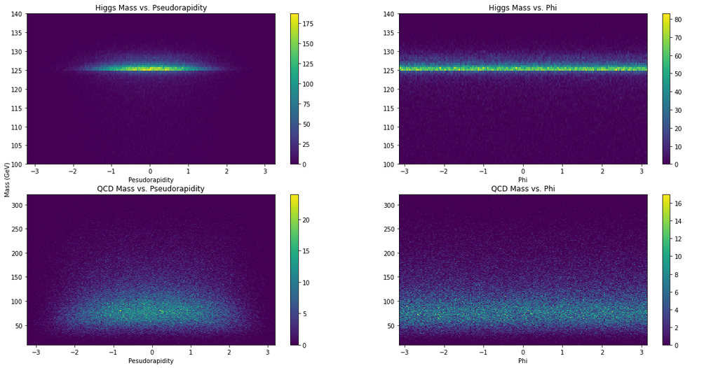

```python
fig,ax = plt.subplots(2,2)
plt.subplot(2,2,1)
plt.hist2d(higgs['eta'],higgs['mass'],250)
plt.title('Higgs Mass vs. Pseudorapidity')
plt.xlabel('Pesudorapidity')
plt.colorbar()
plt.ylim(100, 140)
plt.subplot(2,2,2)
plt.hist2d(higgs['phi'],higgs['mass'],250)
plt.title('Higgs Mass vs. Phi')
plt.xlabel('Phi')
plt.ylim(100, 140)
plt.colorbar()
plt.subplot(2,2,3)
plt.hist2d(qcd['eta'],qcd['mass'],250)
plt.title('QCD Mass vs. Pseudorapidity')
plt.xlabel('Pesudorapidity')
plt.colorbar()
plt.subplot(2,2,4)
plt.hist2d(qcd['phi'],qcd['mass'],250)
plt.title('QCD Mass vs. Phi')
plt.xlabel('Phi')
plt.colorbar()
fig.add_subplot(111, frameon=False)
plt.tick_params(labelcolor='none', top=False, bottom=False, left=False, right=False)
plt.ylabel('Mass (GeV)')
plt.show()
```

The above 4 plots involve plotting jet mass with pseudorapidity and phi for both the Higgs boson and QCD datasets. The biggest difference that jumps out immediately is that the Higgs boson jets have a much smaller range of mass compared to QCD jets. Higgs boson has a mass $m_h=125.09\pm{0.3}GeV$, and it seems from the plot that most of the jet mass is concentrated around that number. As for pseudorapidity vs phi, the pseudorapitity distribution seems to be concentrated towards 0, with the shape resembling a flat bell shape, whereas phi distribution is uniform across. This is reflected on the fact that pseudorapidity $\eta$ is a function of $\theta$ that ranges from 0 to $\pi$, whereas $\phi$ ranges from 0 to 2$\pi$.

Comparing the two features between the two datasets, $\phi$ for both are pretty similar as both are uniform. However, for pseudorapidity, the QCD dataset has a noticeably bigger spread compared to the Higgs boson dataset, which indicates a wider and less predictable scattering than Higgs boson jets.

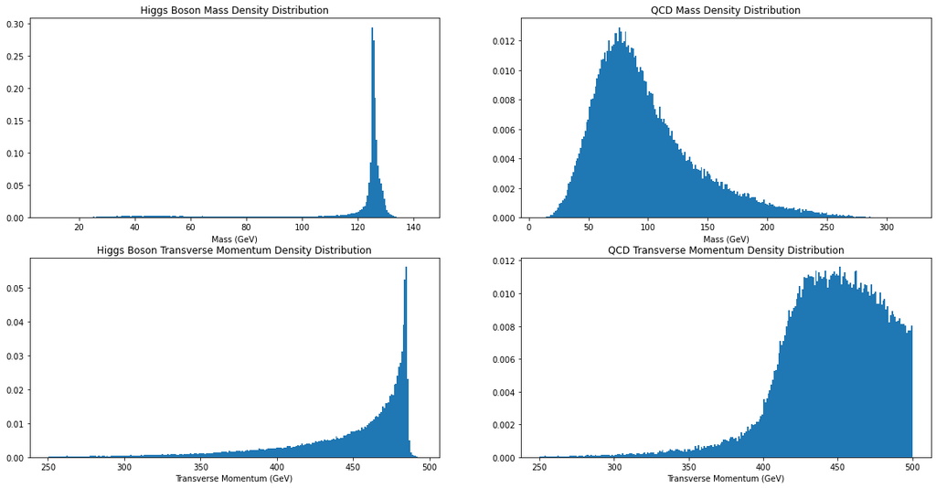

```python
plt.subplots(2,2)
plt.subplot(2,2,1)
plt.hist(higgs['mass'],250,density=True)
plt.title('Higgs Boson Mass Density Distribution')
plt.xlabel('Mass (GeV)')
plt.subplot(2,2,2)
plt.hist(qcd['mass'],250,density=True)
plt.title('QCD Mass Density Distribution')
plt.xlabel('Mass (GeV)')
plt.subplot(2,2,3)
plt.hist(higgs['pt'],250,density=True)
plt.title('Higgs Boson Transverse Momentum Density Distribution')
plt.xlabel('Transverse Momentum (GeV)')
plt.subplot(2,2,4)
plt.hist(qcd['pt'],250,density=True)
plt.title('QCD Transverse Momentum Density Distribution')
plt.xlabel('Transverse Momentum (GeV)')
plt.show()
```

The above 4 plots are the density distribution for both mass and transverse momentum for both Higgs boson and QCD datasets. Again, we can see that the mass distribution for Higgs boson is skewed towards its known mass $m_h$, whereas the QCD mass distribution resembles a Poisson distribution averaged around ~80 GeV. The QCD mass distribution also has almost 2x the range as that of Higgs boson, which was also made clear in the previous color density plots. There also seems to be some relavant noise in the Higgs boson mass distribution in the range 20 to 60 GeV.

As for $p_t$, we can see the expected range of 250 to 500 GeV. For the Higgs boson $p_t$ distribution, the pattern is exponential slope into a cliff around ~480 GeV where the peak is, and then the density rapidly approaches 0. On the other hand, the QCD $p_t$ distribution looks more like a reverse Poisson distribution, and peaks slightly before the Higgs boson distribution at ~450 GeV.

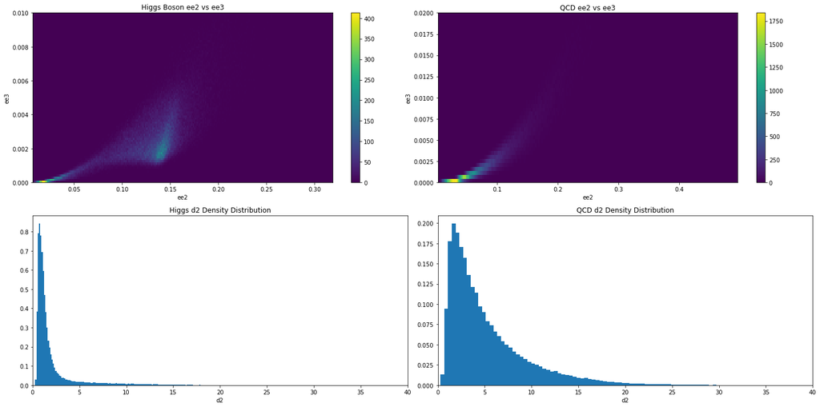

```python
fig,ax = plt.subplots(2,2)
plt.subplot(2,2,1)
plt.hist2d(higgs['ee2'],higgs['ee3'],250)
plt.title('Higgs Boson ee2 vs ee3')
plt.xlabel('ee2')
plt.ylabel('ee3')
plt.ylim(0,0.01)
plt.colorbar()
plt.subplot(2,2,2)
plt.hist2d(qcd['ee2'],qcd['ee3'],250)
plt.title('QCD ee2 vs ee3')
plt.xlabel('ee2')
plt.ylabel('ee3')
plt.ylim(0,0.02)
plt.colorbar()
plt.subplot(2,2,3)
plt.hist(higgs['d2'],250,density=True)
plt.title('Higgs d2 Density Distribution')
plt.xlabel('d2')
plt.xlim(0, 40)
plt.subplot(2,2,4)
plt.hist(qcd['d2'],250,density=True)
plt.title('QCD d2 Density Distribution')
plt.xlabel('d2')
plt.xlim(0, 40)
fig.tight_layout()
plt.show()
```

For the `ee2` vs `ee3` plots, there are some interesting patterns. Both distributions are heavily skewed towards 0, and both slopes upward away from when moving away 0. However, whereas the QCD distribution continues to concave up and slowly fades, the Higgs boson distribution starts to have some sort of fallout effect, creating a dense region in the 0.125 < `ee2` < 0.155 region.

As for the `d2` density distribution, the Higgs boson distribution is overall more tight and much much more skewed towards 0 than the QCD distribution. This suggests that Higgs boson jets are more likely to be 2-prong jets and QCD jets are more likely to be 1-prong jets, which makes sense in terms of signal vs background jets.

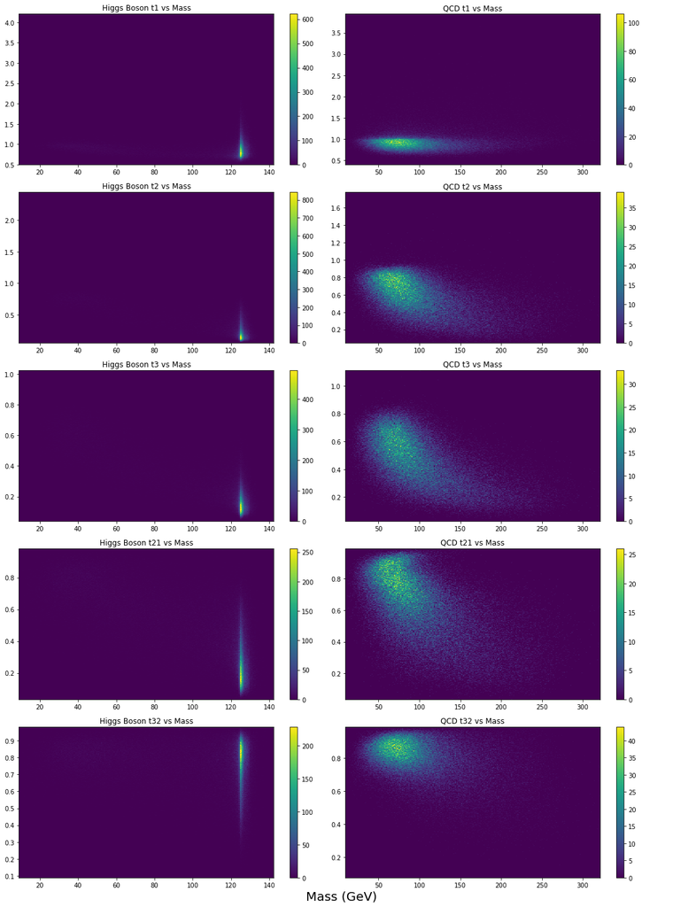

```python
features = ['t1', 't2', 't3', 't21', 't32']
fig,ax = plt.subplots(5,2,figsize=(15,20))
for i in range(5):
    plt.subplot(5,2,(2*i)+1)
    plt.hist2d(higgs['mass'],higgs[features[i]],250)
    plt.title('Higgs Boson ' + features[i] + ' vs Mass')
    plt.colorbar()
    plt.subplot(5,2,(2*i)+2)
    plt.hist2d(qcd['mass'],qcd[features[i]],250)
    plt.title('QCD ' + features[i] + ' vs Mass')
    plt.colorbar()
fig.tight_layout()
fig.add_subplot(111, frameon=False)
plt.tick_params(labelcolor='none', top=False, bottom=False, left=False, right=False)
plt.xlabel('Mass (GeV)',fontsize=20)
plt.show()
```

The above 10 plots involve features relating to N-subjettiness plotted against jet mass. The rows from top to bottom are the in order of `t1`, `t2`, `t3`, `t21` and `t32`. The left column data are pulled from the Higgs boson dataset, whereas the right column QCD dataset.

Comparing the first three rows of plots, we can see the overall $\tau_N$ decreases as N increases, which is expected. As for Higgs boson vs QCD distribution, the Higgs boson distributions tend to always be skewed towards 0, whereas the QCD distributions gradually spread out, with averages increasing relative to their respective subjettiness ranges.

As for the last two rows of the plot, we can see that in the Higgs boson distribution, `t21` is skewed towards 0, while `t32` is skewed towards 1. Since `tnn` is a ratio, the change between 1 and 2 subjets is quite significant, whereas the change between 2 and 3 subjets is quite small. And for the QCD distribution, both `tnn` distributions are skewed towards 1, meaning there isn't much change going from 1 to 2 jets, or 2 to 3 jets. This perhaps reinforces the interpretation from the `d2` distributions that Higgs boson jets are likely 2-prong, while QCD jets are likely 1-prong.

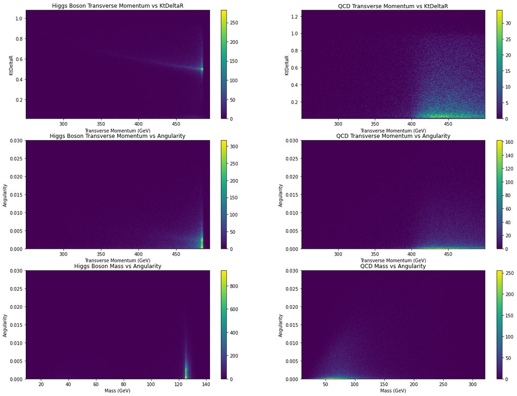

```python
plt.subplots(3,2,figsize=(20,15))
plt.subplot(3,2,1)
plt.hist2d(higgs['pt'],higgs['KtDeltaR'],250)
plt.title('Higgs Boson Transverse Momentum vs KtDeltaR')
plt.xlabel('Transverse Momentum (GeV)')
plt.ylabel('KtDeltaR')
plt.colorbar()
plt.subplot(3,2,2)
plt.hist2d(qcd['pt'],qcd['KtDeltaR'],250)
plt.title('QCD Transverse Momentum vs KtDeltaR')
plt.xlabel('Transverse Momentum (GeV)')
plt.ylabel('KtDeltaR')
plt.colorbar()
plt.subplot(3,2,3)
plt.hist2d(higgs['pt'],higgs['angularity'],250)
plt.title('Higgs Boson Transverse Momentum vs Angularity')
plt.xlabel('Transverse Momentum (GeV)')
plt.ylabel('Angularity')
plt.ylim(0,0.03)
plt.colorbar()
plt.subplot(3,2,4)
plt.hist2d(qcd['pt'],qcd['angularity'],250)
plt.title('QCD Transverse Momentum vs Angularity')
plt.xlabel('Transverse Momentum (GeV)')
plt.ylabel('Angularity')
plt.ylim(0,0.03)
plt.colorbar()
plt.subplot(3,2,5)
plt.hist2d(higgs['mass'],higgs['angularity'],250)
plt.title('Higgs Boson Mass vs Angularity')
plt.xlabel('Mass (GeV)')
plt.ylabel('Angularity')
plt.ylim(0,0.03)
plt.colorbar()
plt.subplot(3,2,6)
plt.hist2d(qcd['mass'],qcd['angularity'],250)
plt.title('QCD Mass vs Angularity')
plt.xlabel('Mass (GeV)')
plt.ylabel('Angularity')
plt.ylim(0,0.03)
plt.colorbar()
fig.tight_layout()
plt.show()
```

Lastly, the above 6 plots involve the left over two features: `KtDeltaR` and `angularity`. Admittedly, I had the hardest time interpreting these two features, and I couldn't find much resources regarding them either.

For the first row of plots, I tried plotting `KtDeltaR` against other features, but it seemed that plotting it against transverse momentum made the most sense, as the clustering algorithm $k_t$ involved both of these features. The Higgs boson distribution is very interesting, as it begins with a somewhat linear relationship between the two features, but as `pt` approaches the peak of ~480 GeV, `KtDeltaR` scatters like a falling snowball hitting a wall. And for the QCD distribution, the distribution is fairly uniform across for `pt` > ~400 GeV, and `KtDeltaR` is skewed towards 0.